# a_s_fermi-dirac gas-Copy1

```python
import numpy as np
import mpmath as mp
import scipy as sp
%matplotlib inline

import matplotlib.pyplot as plt
import matplotlib.pylab as pylab
params = {'legend.fontsize': 'x-large',
          'figure.figsize': (15, 5),
         'axes.labelsize': 'x-large',
         'axes.titlesize':'x-large',
         'xtick.labelsize':'x-large',
         'ytick.labelsize':'x-large'}
pylab.rcParams.update(params)
```

## Распределение Ферми

При достаточно низкой температуре статистика Больцмана становится неприемлимой (средние числа заполнения различных квантовых состояний нельзя считать много меньшми 1).

Эта статистика различна в зависимости от того, какого рода волновыми функциями описывается газ, рассматриваемый как система $N$ одинаковых частиц. Функции могут быть либо антисимметричными, либо симметричными по отношению к перестановкам любой пары частиц, первый сулчай - частицы с полуцелым числом, а второй - частицы с целым спином.

Для системы частиц, описывающейся антисимметричными волновыми функциями, справедлив принцип Паули: в каждом квантовом состоянии может находиться одновременно не более одной частицы. Статистика, основанная на этом принципе, называется *статистикой Ферми-Дирака*. Применим распределение Гиббса к совокупности всех частиц газа, находящихся вданном квантовом состоянии. Обозначим через $\Omega_k$ термодинамический потенциал этой системы:

\begin{equation} \label{1} \Omega_k=-T*ln\sum_{n_k}\left({e^\frac{\mu-\varepsilon_k}{T}}\right)^{n_k} \end{equation}

Согласно принципу Паули числа заполнения могут принимть только два значения: 0, 1. Поэтому получаем:

\begin{equation} \Omega_k=-T*ln\left(1+{e^\frac{\mu-\varepsilon_k}{T}}\right) \end{equation}

Среднее число частиц равно производной от потенциала $\Omega$ по химическому потенциалу $\mu$:

\begin{equation} \overline{n_k}=-\frac{\partial\Omega_k}{\partial\mu}=\frac{1}{e^{\left(\varepsilon_k-\mu\right)/T}+1} \end{equation}

Это и есть функция распределения для *ферми-газа*. Все $\overline{n_k} \leq 1$. При $exp[(\mu - \epsilon_k) / T] << 1$ функция (3) начинает подчиняться распределению Больцмана.

\noindent

## Распределение частиц

Энергия элементарной частицы сводится к кинетической энергии ее поступательного движения:

\begin{equation} \varepsilon=\frac{1}{2 m}\left(p_{x}^{2}+p_{y}^{2}+p_{z}^{2}\right), \end{equation}

Распределение по абсолютной величне импульса:

\begin{equation} dN_p=\frac{gV{p^2}dp}{2\pi^2\hbar\left(e^{\left(\varepsilon_k-\mu\right)/T}+1\right)}, \end{equation}

где $g = 2$ - параметр вырождения, так как нет магнитного поля и спин-орбитального взаимодействия. Используя связь энергии с импульсом $\varepsilon=\frac{p^2}{2m}$, получим распределение по энергии:

\begin{equation}\label{eq:'dN'} dN_\varepsilon=\frac{gVm^{3/2}}{\sqrt{2}\pi^2\hbar^2}\frac{\sqrt{\varepsilon}d\varepsilon}{e^{\left(\varepsilon-\mu\right)/T}+1} \end{equation}

## Полное число частиц

Получается интегрированием последнего выражения (\ref{eq:'dN'}):

\begin{equation}\label{eq:'N'} N=\frac{gVm^{3/2}}{\sqrt{2}\pi^2\hbar^2}\int_0^{\infty}\frac{\sqrt{\varepsilon}d\varepsilon}{e^{\left(\varepsilon-\mu\right)/T}+1} \end{equation}

Вводя новую переменную $\dfrac{\epsilon}{T} = z$, выражение (\ref{eq:'N'}) перепишется в виде:

\begin{equation}\label{eq:'n/v'} \dfrac{N}{V}=\dfrac{g(m T)^{3 / 2}}{\sqrt{2} \pi^{2} \hbar^{3}} \int_{0}^{\infty} \frac{\sqrt{z} d z}{e^{z-(\mu / T)} \pm 1} \end{equation}

Эта формула неявно определяет химический потенциал газа $\mu$ как функцию температуры $T$ и плотности $\dfrac{N}{V}$

## Зависимость температуры от химического потенциала

Если температура $T = 0$, тогда функция распределения равна 1 для всех состояний, энергия которых меньше значения химического потенциала при $T \rightarrow 0 $. Состояния с энергией меньшей химического потенциала при нулевой температуре $\left(\mu_{0}=\epsilon_{F}\right)$ заполнены, при энергии, большей значения химического потенциала - функция распределения равна 0. Функция распределения имеет ступенчатый характер. В формуле \eqref{eq:'n/v'} верхний предел интегрирования вт таком случае $\epsilon_F = \mu$. Интеграл равен:

\begin{equation}\label{eq:'n/v_ef'} \frac{N}{V}=\frac{g(m T)^{3 / 2}}{\sqrt{2} \pi^{2} \hbar^{3}} \int_{0}^{\epsilon_F} \sqrt{z} d z \end{equation}

Отсюда определена энергия Ферми:

\begin{equation}\label{eq:'ef'} \epsilon_{F}=\dfrac{\hbar^{2}}{2 m}\left(\dfrac{3 \sqrt{2}}{4} \pi^{2} \dfrac{N}{V}\right)^{2 / 3} \end{equation}

Температура Ферми:

\begin{equation}\label{eq:'tf'} T_{F}=\dfrac{\hbar^{2}}{2 m k_B}\left(\dfrac{3 \sqrt{2}}{4} \pi^{2} \dfrac{N}{V}\right)^{2 / 3} \end{equation}

При низких температурах из \eqref{eq:'n/v'} и \eqref{eq:'ef'}:

\begin{equation} \label{eq:'1'} \frac{2}{3} \epsilon_{F}^{3 / 2}=T^{\frac{3}{2}} \int_{0}^{\infty} \dfrac{\sqrt{z} dz}{e^{z - \mu(T) / T} + 1} \end{equation}

Для решения данного интеграла численно необходимо обезразмерить величины:

$$\tilde{\mu} = \dfrac{\mu}{T},$$

$$\tilde{T} = \dfrac{T}{T_F}$$

Интеграл \eqref{eq:'1'} есть не что иное, как интеграл Ферми-Дирака

\begin{equation}\label{eq:'fermi integral'} F_{j}(x)=\frac{1}{\Gamma(j+1)} \int_{0}^{\infty} \frac{t^{j}}{e^{t-x}+1} d t \end{equation}

Это альтернативное определение для полилогарифма:

\begin{equation}\label{eq:'poly'} F_{j}(x)=-\mathrm{Li}_{j+1}\left(-e^{x}\right) \end{equation}

Для начала найдем зависимость температуры от химического потенциала:

\begin{equation}\label{eq:'tvsmu'} \dfrac{2}{3}\tilde{T}^{-\frac{3}{2}} = \int_{0}^{\infty} \dfrac{\sqrt{z} dz}{e^{z - \mu(T) / T} + 1} \end{equation}

Перепишем \eqref{eq:'tvsmu'} как:

\begin{equation} I=\int_{0}^{\infty} \frac{\sqrt{z}}{\exp (z-\bar{\mu})+1} d z=\int_{0}^{\infty} \frac{\sqrt{z}}{1+k \exp (z)} d z, \end{equation}

где $k=e^{-\tilde{\mu}}$

\begin{equation}\label{eq:'i'} I=-\frac{\sqrt{\pi}}{2} \operatorname{Li}_{\frac{1}{2}}\left(-\frac{1}{k}\right)=-\frac{\sqrt{\pi}}{2} \operatorname{Li}_{\frac{3}{2}}\left(-e^{\tilde{\mu}}\right) \end{equation}

Для решения можно использовать численный метод, записав

\begin{equation}\label{eq:'fmu'} f(\bar{\mu})=\log \left(-\frac{\sqrt{\pi}}{2} \operatorname{Li}_{\frac{3}{2}}\left(-e^{\tilde{\mu}}\right)\right)-\log \left(\frac{2}{3} \bar{T}^{-\frac{3}{2}}\right) \end{equation}

Из \eqref{eq:'fmu'} зависимость $\tilde{T}(\tilde{\mu})$:

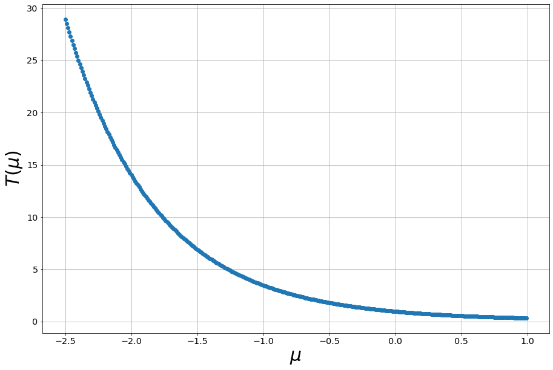

```python
def f(l):
    return (-3 / 4 * np.pi**0.5 * mp.fp.polylog(3/2, -mp.exp(l)))**(-3 / 2)


mu = np.arange(-2.5, 1, 0.01)
#print(mu)
T = []
for x in mu:
     T.append(mp.re(f(x)))


#print(T)
plt.figure(figsize=(15,10))
plt.grid()
plt.xlabel('$\mu$', fontsize='30')
plt.ylabel('$T(\mu)}$', fontsize='30')
plt.plot(mu, T, 'o')
plt.show()
```

```python
#Определяет m(T) при данной температуре

def naive_root(f, t, x_guess, tolerance, step_size):

    steps_taken = 0

    while abs(f(x_guess, t)) > tolerance:
        if f(x_guess, t) > 0:
            x_guess -= step_size
        elif f(x_guess, t) < 0:
            x_guess += step_size
        else:
            return x_guess

        steps_taken += 1

    return x_guess, steps_taken

F = lambda mu, T: np.real(-((3 * np.sqrt(np.pi)) / 4) * (mp.polylog(3 / 2, float(-np.exp(mu / T))))) - T**(-3 / 2)
root, steps = naive_root(F, 0.1, x_guess=9.5, tolerance=0.1, step_size=0.01)
print("root is:", root)
print ("steps taken:", steps)
%timeit naive_root(F, 0.1, x_guess=9.5, tolerance=0.1, step_size=0.01)
```

```
root is: 0.990000000000159
steps taken: 851
7.36 s ± 498 ms per loop (mean ± std. dev. of 7 runs, 1 loop each)
```

Численно можно найти зависимость $\tilde{\mu}(\tilde{T})$

```python
def inverse_quadratic_interpolation(f, t, x0, x1, x2, max_iter, tolerance):
    steps_taken = 0
    while steps_taken < max_iter and abs(x1 - x0) > tolerance:
        fx0 = f(x0, t)
        fx1 = f(x1, t)
        fx2 = f(x2, t)
        L0 = (x0 * fx1 * fx2) / ((fx0 - fx1) * (fx0 - fx2))
        L1 = (x1 * fx0 * fx2) / ((fx1 - fx0) * (fx1 - fx2))
        L2 = (x2 * fx1 * fx0) / ((fx2 - fx0) * (fx2 - fx1))
        new = L0 + L1 + L2
        x0, x1, x2 = new, x0, x1
        steps_taken += 1
    return x0, steps_taken

F = lambda mu, T: np.real(-((3 * np.sqrt(np.pi)) / 4) * np.real(mp.fp.polylog(3 / 2, float(-np.exp(mu)))) - T**(-3 / 2))

root, steps = inverse_quadratic_interpolation(F, 0.1, 9.4, 9.5, 9.6, max_iter=20, tolerance=1e-7)
print("root is:", root)
print("steps taken:", steps)
%timeit inverse_quadratic_interpolation(F, 0.1, 9.4, 9.5, 9.6, max_iter=20, tolerance=1e-7)
```

```
root is: 9.916412363704493
steps taken: 3
1.47 ms ± 65.4 µs per loop (mean ± std. dev. of 7 runs, 1000 loops each)
```

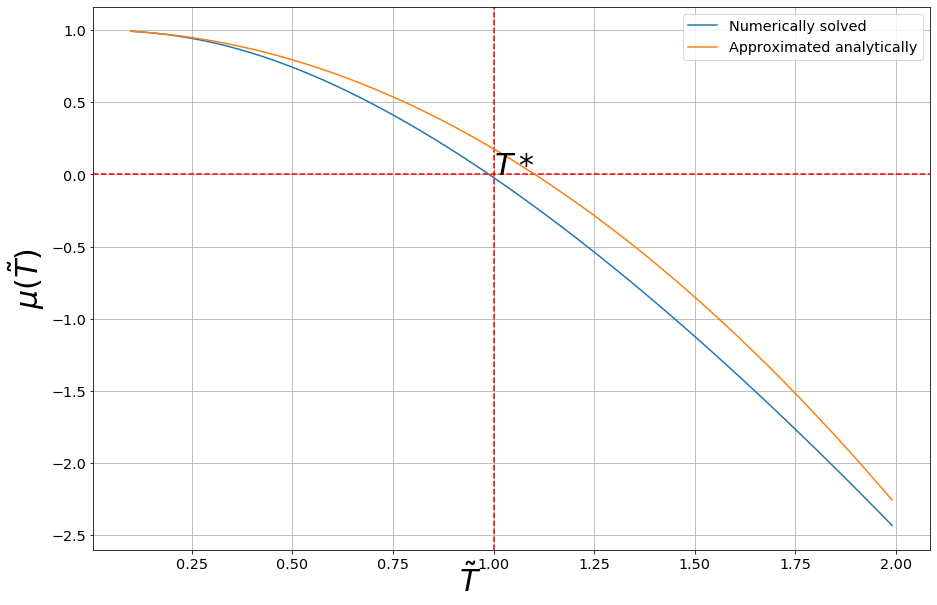

```python
#цикл для построения mu(T):

step = 0.01
T = np.arange(0.1, 2, step)
mu_T = []
for i in T:
    mu_T.append(inverse_quadratic_interpolation(F, i, 9.4 + step, 9.5 + step, 9.6 + step,
                                                 max_iter=200, tolerance=1e-9)[0])

plt.figure(figsize=(15,10))
plt.grid()
plt.xlabel('$\~{T}$', fontsize='30')
ax = plt.gca()
ax.xaxis.set_label_coords(0.45, -0.025)
plt.ylabel('$\mu(\~{T})$', fontsize='30')
plt.plot(T, T * mu_T, label='Numerically solved')
plt.axvline(1, linestyle='--', color='red')
plt.axhline(0, linestyle='--', color='red')
plt.text(1,0, '$T*$', rotation=0, fontsize='30')


#Можно сравнить данную зависимость с приближенной
mu_from_book = lambda T: (1 - np.pi**2 / 12 * (T)**2)
plt.plot(T, mu_from_book(T), label='Approximated analytically')
plt.legend()
plt.show()
#print(mu_T)
```

```
Коэффициент -- a -0.6805
Коэффициент-- b -0.4524
Коэффициент -- c 1.111
Average quadratic deviation -0.0034
```

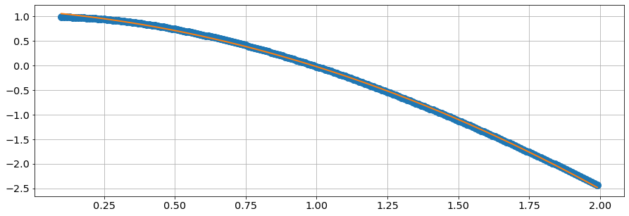

```
m(T) = -0.6805T**2 + -0.4524T + 1.111
```

```python
# Аппроксимация для определения вида функции mu(T)

def mnkGP(x,y):
    d=2 # степень полинома
    fp, residuals, rank, sv, rcond = sp.polyfit(x, y, d, full=True) # Модель
    f = sp.poly1d(fp) # аппроксимирующая функция
    print('Коэффициент -- a %s  '%round(fp[0],4))
    print('Коэффициент-- b %s  '%round(fp[1],4))
    print('Коэффициент -- c %s  '%round(fp[2],4))
    y1=[fp[0]*x[i]**2+fp[1]*x[i]+fp[2] for i in range(0,len(x))] # значения функции a*x**2+b*x+c
    so=round(sum([abs(y[i]-y1[i]) for i in range(0,len(x))])/(len(x)*sum(y))*10,4) # средняя ошибка
    print('Average quadratic deviation '+str(so))
    fx = sp.linspace(x[0], x[-1], 10000*len(x)) # можно установить вместо len(x) большее число для интерполяции
    plt.plot(x, y, 'o', label='Original data', markersize=10)
    plt.plot(fx, f(fx), linewidth=2)
    plt.grid(True)
    plt.show()
    return  round(fp[0],4), round(fp[1],4), round(fp[2],4)

x = T
y = mu_T * T
a, b, c = mnkGP(x, y)

fm = lambda T: a * T**2 + b * T + c
print('m(T) = ', a,'T**2 + ',b, 'T + ', c, sep='')
```

Построение трех графиков

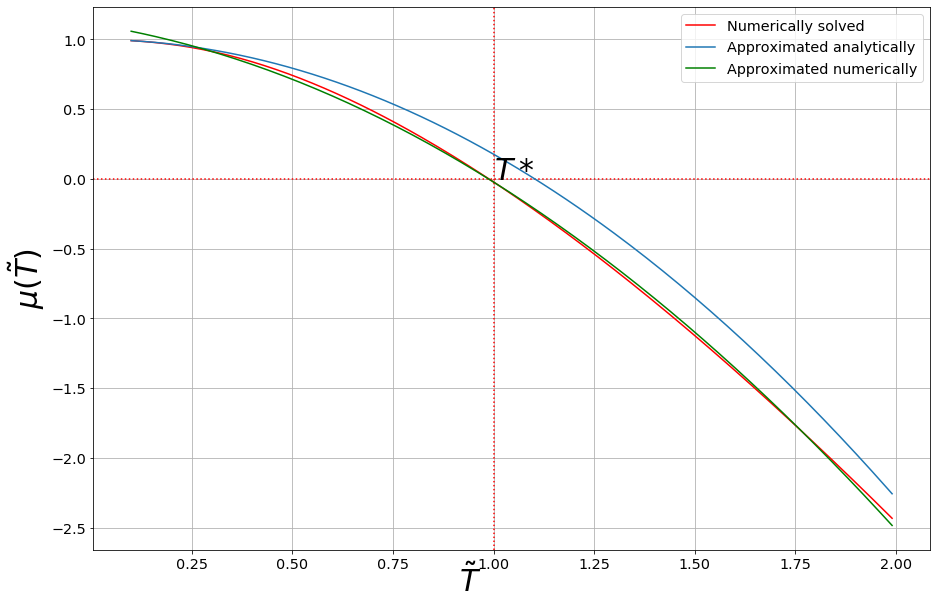

```python
#цикл для построения mu(T):

step = 0.01
T = np.arange(0.1, 2, step)
mu_T = []
for i in T:
    mu_T.append(inverse_quadratic_interpolation(F, i, 9.4 + step, 9.5 + step, 9.6 + step,
                                                 max_iter=20, tolerance=1e-9)[0])
#print(mu_T)

plt.figure(figsize=(15,10))
plt.grid()
plt.xlabel('$\~{T}$', fontsize='30')
ax = plt.gca()
ax.xaxis.set_label_coords(0.45, -0.025)
plt.ylabel('$\mu(\~{T})$', fontsize='30')
plt.plot(T, T * mu_T, label='Numerically solved', color='red')
plt.axvline(1, linestyle='dotted', color='red')
plt.axhline(0, linestyle='dotted', color='red')
plt.text(1,0, '$T*$', rotation=0, fontsize='30')



#Можно сравнить данную зависимость с приближенной
mu_from_book = lambda T: (1 - np.pi**2 / 12 * (T)**2)
plt.plot(T, mu_from_book(T), label='Approximated analytically')


#Найденная из аппроксимации функция
plt.plot(T, fm(T), label='Approximated numerically', color='green')
plt.legend()
plt.show()
```

Необходимо определить, когда химический потенциал меняет свой знак: Функция пересекает еоль только один раз, поэтому, можно использовать метод дихотомии для отыскания корня, предварительно взглянув на график

```python
def bisection(f, a, b, eps=1e-7):

    if f(a)*f(b) >= 0:
        print("Bisection method fails.")
        return None
    a_n = a
    b_n = b
    steps = 0
    while abs(b_n - a_n) > eps:
        m_n = (a_n + b_n) / 2
        f_m_n = f(m_n)
        if f(a_n) * f_m_n < 0:
            a_n = a_n
            b_n = m_n
        elif f(b_n) * f_m_n < 0:
            a_n = m_n
            b_n = b_n
        elif f_m_n == 0:
            print("Found exact solution.")
            return m_n
        else:
            print("Bisection method fails.")
            return None
        steps += 1
    return (a_n + b_n) / 2, steps

T_star = bisection(fm, 0.75, 1.5)[0]
print('T*/T_F = ', T_star, '- Точка смены знака mu')
```

```
T*/T_F =  0.987867996096611 - Точка смены знака mu
```

### Зная функцию $\tilde{\mu}(\tilde{T})$, необходимо найти интеграл, определяющий полное число частиц

## Полная энергия

\begin{equation}\label{eq:'E'} E=\int_0^{\infty}\varepsilon dN_\varepsilon=\frac{gVm^{3/2}}{\sqrt{2}\pi^2\hbar^2}\int_0^{\infty}\frac{\varepsilon^{3/2}d\varepsilon}{e^{\left(\varepsilon-\mu(\tilde{T})\right)/\tilde{T}}+1} \end{equation}

Тогда плотность энергии: $\frac{E}{N}$:

\begin{equation}\label{eq:'E/N'} e \equiv \dfrac{E(\tilde{T})}{N} = \dfrac{\frac{gVm^{3/2}}{\sqrt{2}\pi^2\hbar^2}\int_0^{\infty}\frac{\varepsilon^{3/2}d\varepsilon}{e^{\left(\varepsilon-\mu(\tilde{T})\right)/\tilde{T}}+1}}{\frac{gVm^{3/2}}{\sqrt{2}\pi^2\hbar^2}\int_0^{\infty}\frac{\varepsilon^{1/2}d\varepsilon}{e^{\left(\varepsilon-\mu(\tilde{T})\right)/\tilde{T}}+1}} = \dfrac{-\tilde{T}^\frac{5}{2} \Gamma\left( \dfrac{5}{2}\right) \operatorname{Li}_{\frac{5}{2}}\left(-e^{\tilde{\mu}(\tilde{T})}\right)}{-\tilde{T}^\frac{3}{2} \Gamma\left( \dfrac{3}{2}\right) \operatorname{Li}_{\frac{3}{2}}\left(-e^{\tilde{\mu}(\tilde{T})}\right)} =\tilde{T} \dfrac{\Gamma\left( \dfrac{5}{2}\right) \operatorname{Li}_{\frac{5}{2}}\left(-e^{\tilde{\mu}(\tilde{T})}\right)}{\Gamma\left( \dfrac{3}{2}\right) \operatorname{Li}_{\frac{3}{2}}\left(-e^{\tilde{\mu}(\tilde{T})}\right)} \end{equation}

```python
en = []
tt = np.arange(0.01, 10, 0.001)
print(tt)
def e1(T):
    return (mp.re(T * (mp.gamma(5 / 2) * mp.fp.polylog(5 / 2, - mp.exp(fm(T) / T))) /
                 (mp.gamma(3 / 2) * mp.fp.polylog(3 / 2, - mp.exp(fm(T) / T)))))

e1(0.01)

for t in tt:
    en.append(e1(t))



def e_from_book(T):

    return (mp.re(T * (mp.gamma(5 / 2) * mp.fp.polylog(5 / 2, - mp.exp(mu_from_book(T) / T))) /
                 (mp.gamma(3 / 2) * mp.fp.polylog(3 / 2, - mp.exp(mu_from_book(T) / T)))))

en_from_book = []

for t in tt:
    en_from_book.append(e_from_book(t))
```

```
[0.01  0.011 0.012 ... 9.997 9.998 9.999]
```

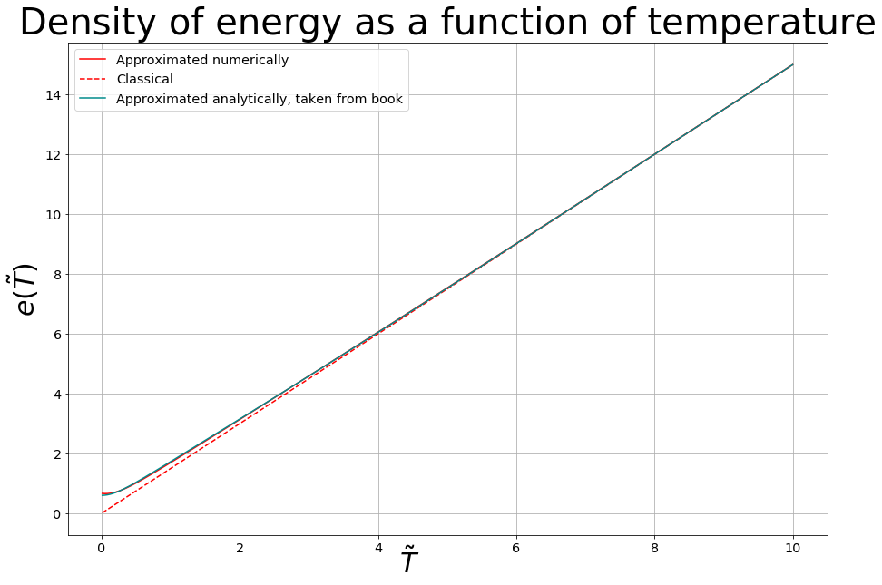

```python
plt.figure(figsize=(15,10))
plt.grid()
plt.title('Density of energy as a function of temperature', fontsize='40')
plt.xlabel('$\~{T}$', fontsize='30')
ax = plt.gca()
ax.xaxis.set_label_coords(0.45, -0.025)
plt.ylabel('$e(\~{T})$', fontsize='30')
plt.plot(tt, en, label='Approximated numerically', color='red')
plt.plot(tt,  3 / 2 * tt, label='Classical', color='red', linestyle='--')
plt.plot(tt, en_from_book, label='Approximated analytically, taken from book', color='darkcyan')
plt.legend()
plt.show()
```

## 2

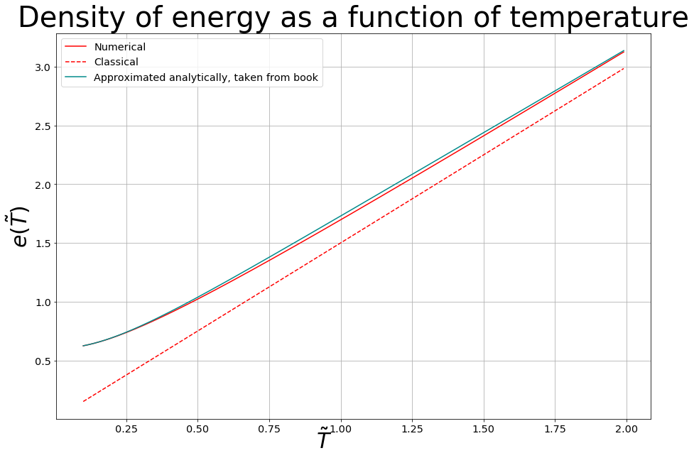

```python
t_and_mu = dict()

for t, mu in zip(T, mu_T):
    t_and_mu[t] = mu

#print(t_and_mu)


def e(T):
    return (mp.re(T * (mp.gamma(5 / 2) * mp.fp.polylog(5 / 2, - mp.exp(t_and_mu[T]))) /
                 (mp.gamma(3 / 2) * mp.fp.polylog(3 / 2, - mp.exp(t_and_mu[T])))))
ep = []

for t in T:
    ep.append(float(e(t)))


en_from_book1 = []

for t in T:
    en_from_book1.append(e_from_book(t))


plt.figure(figsize=(15,10))
plt.grid()
plt.title('Density of energy as a function of temperature', fontsize='40')
plt.xlabel('$\~{T}$', fontsize='30')
ax = plt.gca()
ax.xaxis.set_label_coords(0.45, -0.025)
plt.ylabel('$e(\~{T})$', fontsize='30')
plt.plot(T, ep, label='Numerical', color='red')
plt.plot(T,  3 / 2 * T, label='Classical', color='red', linestyle='--')
plt.plot(T, en_from_book1, label='Approximated analytically, taken from book',
         color='darkcyan')
plt.legend()
plt.show()
```